# Exercise: Regularization and Bayesian Shrinkage

### 4.5 Code

```r
# Ridge baseline on prostate (automatically standardizes data)
ridge_pros  <- lm.ridge(lpsa ~ ., data = pros, lambda = seq(0, 5, by = 0.01))
lambda_pros <- as.numeric(names(which.min(ridge_pros$GCV)))
ridge_pros  <- lm.ridge(lpsa ~ ., data = pros, lambda = lambda_pros)
ridge_beta_pros <- coef(ridge_pros)[-1]
cat("prostate ridge lambda (GCV):", lambda_pros)
```

```
prostate ridge lambda (GCV): 5
```

```r
fit_lasso <- brm(
  lpsa ~ .,
  data  = pros,
  prior = c(
    set_prior("double_exponential(0, 1)", class = "b"),
    set_prior("normal(0, 1)",             class = "Intercept"),
    set_prior("exponential(1)",           class = "sigma")
  ),
  chains = 3, iter = 3000, warmup = 1000,
  seed = 42, backend = "rstan", refresh = 0
)
```

```r
# par_ratio = p0 / (p - p0): prior guess that ~3 of 8 predictors are non-zero
fit_hs <- brm(
  lpsa ~ .,
  data  = pros,
  prior = c(
    set_prior("horseshoe(df = 1, par_ratio = 0.6)", class = "b"),
    set_prior("normal(0, 1)",                       class = "Intercept"),
    set_prior("exponential(1)",                     class = "sigma")
  ),
  chains = 3, iter = 3000, warmup = 1000,
  seed = 42, backend = "rstan", refresh = 0,
  control = list(adapt_delta = 0.99)   # horseshoe needs higher adapt_delta
)
```

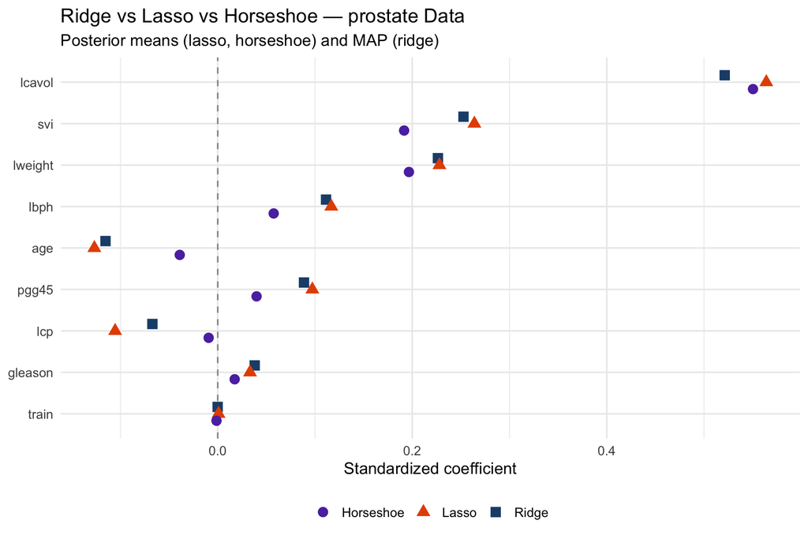

```r
# Collect posterior means from all three methods
fe_lasso <- fixef(fit_lasso)
fe_hs    <- fixef(fit_hs)
preds_p  <- colnames(pros)[colnames(pros) != "lpsa"]

all_coefs <- bind_rows(
  tibble(Predictor = preds_p, Estimate = ridge_beta_pros,              Method = "Ridge"),
  tibble(Predictor = preds_p, Estimate = fe_lasso[preds_p, "Estimate"], Method = "Lasso"),
  tibble(Predictor = preds_p, Estimate = fe_hs[preds_p,    "Estimate"], Method = "Horseshoe")
)

ggplot(all_coefs,
       aes(x = reorder(Predictor, abs(Estimate)),
           y = Estimate, color = Method, shape = Method)) +
  geom_hline(yintercept = 0, linetype = "dashed", color = "grey60") +
  geom_point(size = 3.5, position = position_dodge(0.5)) +
  coord_flip() +
  scale_color_manual(values = c(Ridge = "#1F4E79", Lasso = "#E65100",
                                Horseshoe = "#5E35B1")) +
  labs(title   = "Ridge vs Lasso vs Horseshoe — prostate Data",
       subtitle = "Posterior means (lasso, horseshoe) and MAP (ridge)",
       x = NULL, y = "Standardized coefficient") +
  theme_minimal(base_size = 13) +
  theme(legend.position = "bottom", legend.title = element_blank())
```

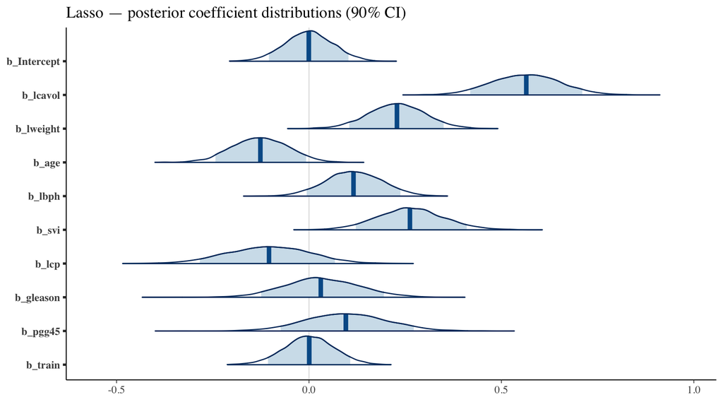

```r
library(bayesplot)

mcmc_areas(fit_lasso, pars = vars(starts_with("b_")), prob = 0.90) +
  labs(title = "Lasso — posterior coefficient distributions (90% CI)")
```

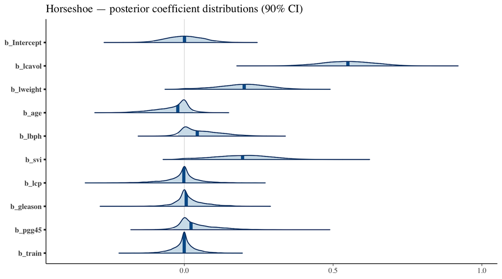

```r
mcmc_areas(fit_hs, pars = vars(starts_with("b_")), prob = 0.90) +
  labs(title = "Horseshoe — posterior coefficient distributions (90% CI)")
```

### 4.6 Exercises

**Q3.1** Run OLS (`lm(lpsa ~ ., data = pros)`) and inspect the $t$-statistics. Which predictors appear important? Which are near-noise? Use this as your reference for evaluating what lasso and horseshoe should do.

**TipHint**

**Q3.2** Compare the three methods in the coefficient plot. Which predictors does lasso shrink most aggressively? Does horseshoe agree with lasso on which predictors are near-zero? Try increasing the aggressiveness of the regularization in each. Can you observe overshrinkage in the selected predictors compared to the horseshoe?

**TipHint**

- Lasso applies uniform shrinkage pressure (same $\tau$ for all). If two correlated predictors both matter, lasso may arbitrarily shrink one more than the other.
- Horseshoe uses per-predictor $\lambda_j$. A predictor with a large signal can have a large local scale and escape global shrinkage entirely.
- Smaller $\tau$ equals more aggressive shrinkage. Use `loo_compare()` as we did before to justify your decision.

**Q3.3** Plot the posterior distributions of all coefficients for lasso and horseshoe using `mcmc_areas()`. For a near-noise predictor (e.g. `age` or `gleason`), describe the shape of the posterior under each prior. What is qualitatively different about lasso vs horseshoe posterior shapes for small coefficients?

**TipHint**

- Lasso posteriors for small coefficients are peaked near zero but still unimodal — the Laplace prior pulls toward zero but does not produce a spike-and-slab shape.
- Horseshoe posteriors for small coefficients often show a sharp spike at zero plus a very light tail — this is the spike-and-slab behavior emerging from the HalfCauchy local scales.
- For large coefficients (`lcavol`), both priors should produce posteriors that are largely uninhibited by the regularization.

**Q3.4** Use `loo()` from the `loo` package to compare lasso and horseshoe by LOO. Which model predicts better out-of-sample? Is the difference larger than $2 \times$ SE?

**TipHint**

```r
library(loo)
loo_lasso <- loo(fit_lasso)
loo_hs    <- loo(fit_hs)
loo_compare(loo_lasso, loo_hs)
```

**Q3.5** Sensitivity check: change `par_ratio` in the horseshoe from 0.6 (3 of 8 non-zero expected) to 0.2 (fewer non-zero expected) and refit. How do the posterior estimates for `lcavol` and `age` change? What does this tell you about how much the data vs the prior is driving the horseshoe results?

**TipHint**

- If `lcavol` barely changes but `age` changes substantially, the horseshoe is prior-sensitive for weak signals but not for strong ones.
- For the horseshoe, the global scale prior (`par_ratio`) matters for borderline predictors, not for clearly strong or clearly zero ones. For $n = 97$ some prior sensitivity could occur for borderline predictors. Do you detect prior sensitivity.

## 5 Summary

**ImportantKey Takeaways**

Every penalized regression method corresponds to a Bayesian model with a specific prior shape on the coefficients:

| Prior shape | Tail behavior | Sparsity | Frequentist penalty |
| --- | --- | --- | --- |
| $\mathcal{N}(0, \tau^2)$ | Light | None | L2 (ridge) |
| DoubleExponential$(0, \tau)$ | Heavier | Moderate | L1 (lasso) |
| Horseshoe | Very heavy | Strong | No exact analogue |

- The penalty parameter $\lambda$ is not a nuisance to be selected by CV — it encodes how strongly we believe coefficients should be small. GCV and Bayesian LOO comparison typically agree when the data are informative about $\lambda$.
- Full Bayesian inference adds honest uncertainty quantification: a flat LOO comparison across models means the data do not prefer any particular level of regularization, which a GCV point estimate would hide.
- The horseshoe prior is the state-of-the-art choice when sparsity is expected and the true number of signals is unknown. It is adaptive allowing large coefficients to escape shrinkage entirely while driving near-zero coefficients to the spike. The horseshoe prior has been shown to outperform lasso, ridge, and non-adaptive shrinkage priors in simulations and real-world sparse settings (e.g., [Piironen and Vehtari, 2017](https://doi.org/10.1214/17-EJS1337SI)).

*Applied Bayesian Methods — Day 1*